# Exploratory Data Analysis on New York Times website clicks

2015-03-21

### Introduction:

Chapter 2: Doing Data Science exercise on EDA.

### Data:

The loaded dataset (nytData) represents one (simulated) day’s worth of ads shown and clicks recorded on the New York Times home page in May 2012. Each row represents a single user. There are five columns: Age, Gender (0=female, 1=male), Impressions, Clicks and Signed-In.

```r
head(nytData)
```

```
##   Age Gender Impressions Clicks Signed_In
## 1  36      0           3      0         1
## 2  73      1           3      0         1
## 3  30      0           3      0         1
## 4  49      1           3      0         1
## 5  47      1          11      0         1
## 6  47      0          11      1         1
```

### Let’s do some EDA

1. Create a new variable, AgeGroup, that categorizes users as “<18”, “18-24”, “25-34”, “35-44”, “45-54”, “55-64”, and “65+”

```r
nytData$AgeGroup = cut(nytData$Age, c(-Inf, 17, 24, 34, 44, 54, 64, Inf), c("<18", "18-24", "25-34", "35-44", "45-54", "55-64", "65+"))
head(nytData)
```

```
##   Age Gender Impressions Clicks Signed_In AgeGroup
## 1  36      0           3      0         1    35-44
## 2  73      1           3      0         1      65+
## 3  30      0           3      0         1    25-34
## 4  49      1           3      0         1    45-54
## 5  47      1          11      0         1    45-54
## 6  47      0          11      1         1    45-54
```

To ensure that Gender variable remains readable we turn it as factor

```r
nytData$Gender = factor(nytData$Gender, levels=c(0,1), labels = c("female", "male"))
head(nytData)
```

```
##   Age Gender Impressions Clicks Signed_In AgeGroup
## 1  36 female           3      0         1    35-44
## 2  73   male           3      0         1      65+
## 3  30 female           3      0         1    25-34
## 4  49   male           3      0         1    45-54
## 5  47   male          11      0         1    45-54
## 6  47 female          11      1         1    45-54
```

2. For a single day
- Plot the distributions of numbers impressions and click-through-rate (CTR = #Clicks/#Impressions) for age categories.

```r
installed.packages("ggplot2")
```

```
##      Package LibPath Version Priority Depends Imports LinkingTo Suggests
##      Enhances License License_is_FOSS License_restricts_use OS_type Archs
##      MD5sum NeedsCompilation Built
```

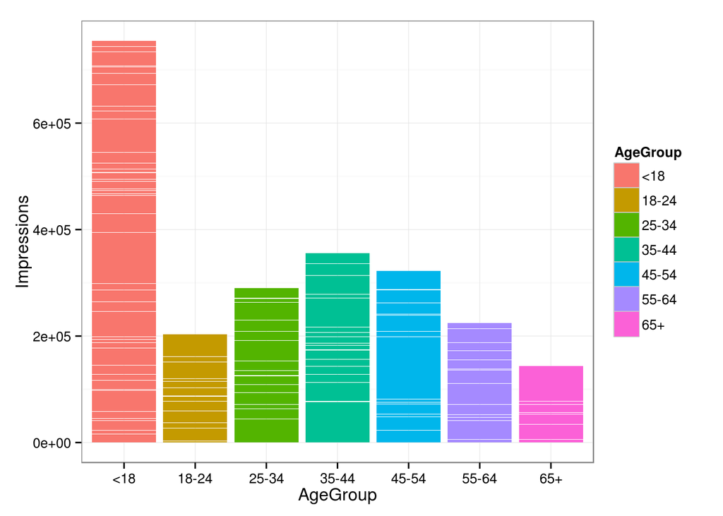

```r
library(ggplot2)
ggplot(data=nytData, aes(x=AgeGroup, y=Impressions, fill=AgeGroup)) + geom_bar(stat="identity") + theme_bw()
```

But wait. It seems the category “<18” is over-represented in the dataset, which might be counter-intuitive considering these data come from the New York Times home page. So let’s inspect more narrowly our dataset.

```r
table(nytData$AgeGroup, nytData$Signed_In)
```

```
##
##              0      1
##   <18   137106  13828
##   18-24      0  40694
##   25-34      0  58174
##   35-44      0  70860
##   45-54      0  64288
##   55-64      0  44738
##   65+        0  28753
```

```r
table(nytData$Gender, nytData$Signed_In)
```

```
##
##               0      1
##   female 137106 153070
##   male        0 168265
```

We concluded that only signed in users have ages and genders so we should not rely on values for unsigned users.

```r
nytData$AgeGroup[nytData$Signed_In == 0] = NA
nytData$Gender[nytData$Signed_In == 0] = NA
summary(nytData)
```

```
##       Age            Gender        Impressions         Clicks
##  Min.   :  0.00   female:153070   Min.   : 0.000   Min.   :0.00000
##  1st Qu.:  0.00   male  :168265   1st Qu.: 3.000   1st Qu.:0.00000
##  Median : 31.00   NA's  :137106   Median : 5.000   Median :0.00000
##  Mean   : 29.48                   Mean   : 5.007   Mean   :0.09259
##  3rd Qu.: 48.00                   3rd Qu.: 6.000   3rd Qu.:0.00000
##  Max.   :108.00                   Max.   :20.000   Max.   :4.00000
##
##    Signed_In         AgeGroup
##  Min.   :0.0000   35-44  : 70860
##  1st Qu.:0.0000   45-54  : 64288
##  Median :1.0000   25-34  : 58174
##  Mean   :0.7009   55-64  : 44738
##  3rd Qu.:1.0000   18-24  : 40694
##  Max.   :1.0000   (Other): 42581
##                   NA's   :137106
```

Now, by replotting the distributions of Impressions we can clearly distinguish important categories.

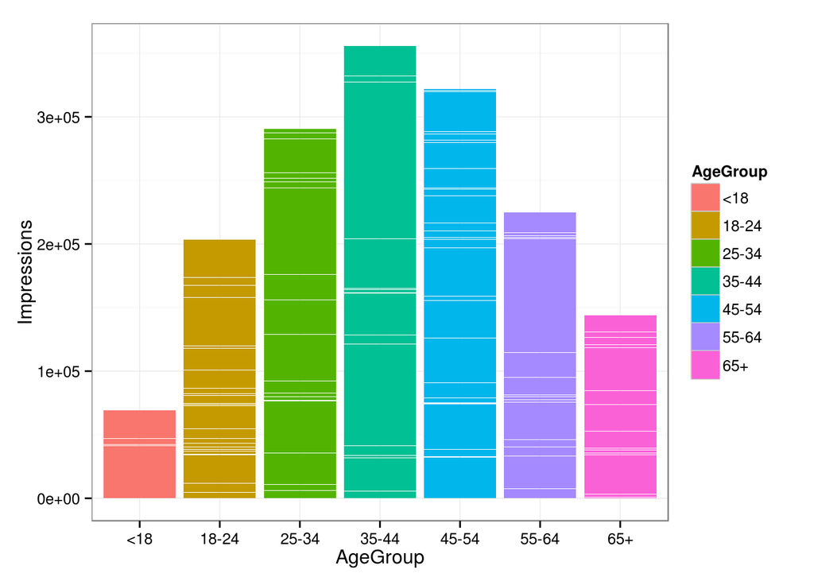

```r
ggplot(data=na.omit(nytData), aes(x=AgeGroup, y=Impressions, fill=AgeGroup)) + geom_bar(stat="identity") + theme_bw()
```

Plot the distributions of Click-through-rate according to age category. We dont’ care about clicks if there are no impressions. So far, we use the whole dataset to make plot but it may slow down the image processing and our analysis. Let’s group data by AgeGroup and count the Impressions and Clicks

```r
library(dplyr)
```

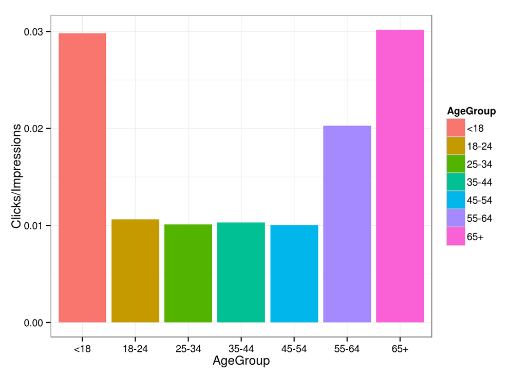

```r
nytSummaryPerAge = na.omit(subset(nytData, Impressions>0)) %>% group_by(AgeGroup) %>% summarise(Impressions = sum(Impressions), Clicks = sum(Clicks))
ggplot(data=nytSummaryPerAge, aes(x=AgeGroup, y=Clicks/Impressions, fill=AgeGroup)) + geom_bar(stat="identity") + theme_bw()
```

Based on the graph above, it suggests that “<18” and “65+” people are more likely to click on ads. However, when it is comme to data exploration process, we want to understand the data and gain good intuition about the process that generated the data. We will split the population into two user segments and check if the CTR remains the same. The user behaviour can be segmented in two groups: 1) Impressions and no click 2) Impressions and at least one click.

- Define a new variable to segment or categorize users based on their click behaviour.

```r
nytData$UserSegment[nytData$Impressions > 0] = "ImpsNoClick"
nytData$UserSegment[nytData$Clicks > 0] = "Imps&Clicks"
nytData$UserSegment = factor(nytData$UserSegment)
summary(nytData$UserSegment)
```

```
## Imps&Clicks ImpsNoClick        NA's
##       39838      415537        3066
```

- Explore the data and make visual and quantitative comparisons across user segements/demographics.

```r
nytCompressedData = na.omit(nytData) %>% group_by(AgeGroup, UserSegment, Gender) %>% summarise(Impressions = sum(Impressions), Clicks = sum(Clicks))
head(nytCompressedData)
```

```
## Source: local data frame [6 x 5]
## Groups: AgeGroup, UserSegment
##
##   AgeGroup UserSegment Gender Impressions Clicks
## 1      <18 Imps&Clicks female        3830    683
## 2      <18 Imps&Clicks   male        7626   1382
## 3      <18 ImpsNoClick female       17970      0
## 4      <18 ImpsNoClick   male       39813      0
## 5    18-24 Imps&Clicks female        5809   1002
## 6    18-24 Imps&Clicks   male        6852   1165
```

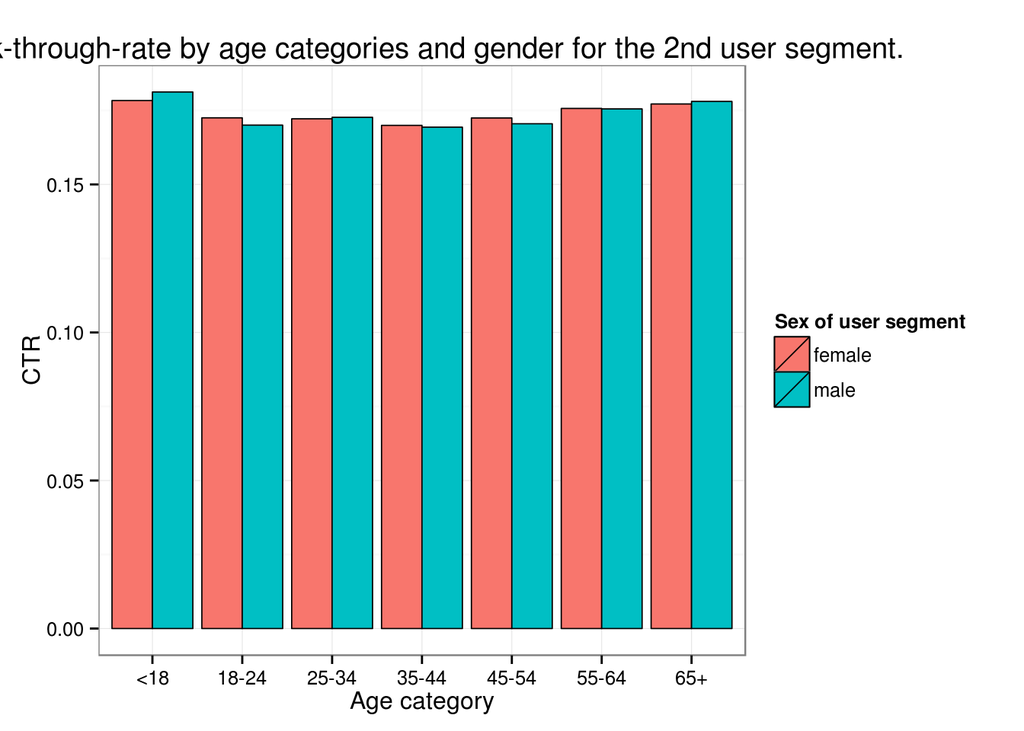

```r
ggplot(data=subset(nytCompressedData,UserSegment == "Imps&Clicks"), aes(x=AgeGroup, y=Clicks/Impressions, fill=Gender)) +
  geom_bar(colour="black", stat="identity", position=position_dodge(), size=0.3) +
  scale_fill_hue(name="Sex of user segment") +
  xlab("Age category") +
  ylab("CTR") +
  ggtitle("Click-through-rate by age categories and gender for the 2nd user segment.") +
  theme_bw()
```

### Conclusion:

By segmenting users in according to their behaviours, we conclude that click-through-rate does not vary significantly by age and gender.